# Congressional Cosponsorship Networks

Holden Huntzinger -- 1/17/23

The code snippets below represent small pieces of a larger solo data mining project. You can find the rest of that project, including relevant data files and Python scripts as well as a conference-style poster and a formal written report, at https://github.com/hhuntz/congressional_networks.

The code below pulls in CSVs from the 'data' folder there. Those come from additional sources (Congress.gov and Propublica, full citations on Github) as well as the compile_data.py script I wrote to turn bill-level data into edges between MOCs.

## Summary

I cast sponsorship information from 325,000 bills across 20 Congressional sessions 1973 - 2021 as a network. MOCs became nodes and the weights of their edges represented the frequency of cosponsorships.

Democrats were more likely to cosponsor bills across party lines; a T-test demonstrates this difference as statistically significant.

More 'legislatively central' Republicans (by pagerank, a form of eigenvector centrality) tend to cosponsor within their party while more central Democrats engage in more cross-party cosponsorship. A 2-way ANOVA shows the statistical significance of this relationship.

I know how to make cool interactive graphs.

## Network Analysis

```python
# for reading and wrangling data
import pandas as pd
import numpy as np
import json

# for visualization
import networkx as nx
import seaborn as sns
import matplotlib.pyplot as plt
%matplotlib inline
import altair as alt

# for hypothesis testing
from scipy.stats import ttest_ind
import statsmodels.api as sm
import statsmodels.formula.api as smf

# ignore warnings
import warnings
warnings.filterwarnings('ignore')
```

```python
# create network
df = pd.read_csv('data/edges.csv', names = ['from', 'to', 'weight'], index_col = False)
G = nx.from_pandas_edgelist(df, source = 'from', target = 'to', create_using = nx.DiGraph(), edge_attr='weight')
```

```python
# load MOC data
moc = pd.read_csv('data/legislators.csv',
                  dtype = {'district': 'Int64'})
moc = moc.drop(['full_name', 'middle_name', 'suffix', 'url', 'address', 'phone',
       'contact_form', 'rss_url', 'twitter', 'facebook', 'youtube',
       'youtube_id', 'opensecrets_id', 'lis_id',
       'fec_ids', 'cspan_id', 'govtrack_id', 'votesmart_id', 'ballotpedia_id',
       'washington_post_id', 'icpsr_id', 'wikipedia_id'], axis = 1)
moc.tail()
```

|  | Unnamed: 0 | last_name | first_name | nickname | birthday | gender | type | state | district | senate_class | party | bioguide_id | thomas_id |
| --- | --- | --- | --- | --- | --- | --- | --- | --- | --- | --- | --- | --- | --- |
| 12593 | 533 | Finstad | Brad | NaN | 1976-05-30 | M | rep | MN | 1 | NaN | Republican | F000475 | NaN |
| 12594 | 534 | Peltola | Mary | NaN | 1973-08-31 | F | rep | AK | 0 | NaN | Democrat | P000619 | NaN |
| 12595 | 535 | Ryan | Patrick | NaN | 1982-03-28 | M | rep | NY | 19 | NaN | Democrat | R000579 | NaN |
| 12596 | 536 | Sempolinski | Joseph | NaN | 1982-02-10 | M | rep | NY | 23 | NaN | Republican | S001219 | NaN |
| 12597 | 537 | Yakym | Rudy | NaN | 1984-02-24 | M | rep | IN | 2 | NaN | Republican | Y000067 | NaN |

```python
# get pagerank
rank = nx.pagerank(G)
features = pd.DataFrame(list(rank.keys()), columns = ['id'])
features['pagerank'] = rank.values()
features.head()
```

|  | id | pagerank |
| --- | --- | --- |
| 0 | 181 | 0.000264 |
| 1 | 513 | 0.000157 |
| 2 | 528 | 0.000674 |
| 3 | 570 | 0.000133 |
| 4 | 656 | 0.000146 |

```python
# combine network measures with MOC info
df1 = features.merge(moc, how = 'left', left_on = 'id', right_on = 'thomas_id')
features.id = features.id.astype('string')
df2 = features.merge(moc, how = 'left', left_on = 'id', right_on = 'bioguide_id')
df = df1.combine_first(df2)

# drop extra column; reset index
df = df.drop(['Unnamed: 0'], axis = 1)
df = df.set_index('id')

df.head()
```

| id | pagerank | last_name | first_name | nickname | birthday | gender | type | state | district | senate_class | party | bioguide_id | thomas_id |
| --- | --- | --- | --- | --- | --- | --- | --- | --- | --- | --- | --- | --- | --- |
| 181 | 0.000264 | Carter | Tim | NaN | 1910-09-02 | M | rep | KY | 5 | NaN | Republican | C000201 | 181.0 |
| 513 | 0.000157 | Hastings | James | NaN | 1926-04-10 | M | rep | NY | 39 | NaN | Republican | H000327 | 513.0 |
| 528 | 0.000674 | Heinz | Henry | NaN | 1938-10-23 | M | sen | PA | <NA> | 1.0 | Republican | H000456 | 528.0 |
| 570 | 0.000133 | Hudnut | William | NaN | 1932-10-17 | M | rep | IN | 11 | NaN | Republican | H000906 | 570.0 |
| 656 | 0.000146 | Kyros | Peter | NaN | 1925-07-11 | M | rep | ME | 1 | NaN | Democrat | K000356 | 656.0 |

## Visualization

I'm skipping some additional computational steps and starting with cleaned data here because some of the additional wrangling and feature generation takes too much time to run.

```python
# get data
df = pd.read_csv('data/MOC_features.csv')
df = df.drop('Unnamed: 0', axis = 1) # drop extraneous column
df.head()
```

|  | first_name | last_name | nickname | birthday | gender | type | state | district | senate_class | party | ... | bipartisan_cosponsorship_score | pagerank | clustering | centrality | closeness | betweenness | congresses | avg_congress | birthyear | since_111 |
| --- | --- | --- | --- | --- | --- | --- | --- | --- | --- | --- | --- | --- | --- | --- | --- | --- | --- | --- | --- | --- | --- |
| 0 | Tim | Carter | NaN | 1910-09-02 | M | rep | KY | 5.0 | NaN | Republican | ... | 0.436504 | 0.000157 | 0.788433 | 0.398574 | 0.312620 | 0.000034 | [89, 90, 91, 92, 93, 94, 95, 96] | 92.5 | 1910.0 | False |
| 1 | James | Hastings | NaN | 1926-04-10 | M | rep | NY | 39.0 | NaN | Republican | ... | 0.449547 | 0.000094 | 0.864077 | 0.301158 | 0.297010 | 0.000012 | [91, 92, 93, 94] | 92.5 | 1926.0 | False |
| 2 | Henry | Heinz | NaN | 1938-10-23 | M | sen | PA | NaN | 1.0 | Republican | ... | 0.424296 | 0.000406 | 0.572125 | 0.399168 | 0.316033 | 0.001627 | [92, 93, 94, 95, 96, 97, 98, 99, 100, 101, 102] | 97.0 | 1938.0 | False |
| 3 | William | Hudnut | NaN | 1932-10-17 | M | rep | IN | 11.0 | NaN | Republican | ... | 0.514981 | 0.000080 | 0.909239 | 0.238194 | 0.284927 | 0.000005 | [93] | 93.0 | 1932.0 | False |
| 4 | Peter | Kyros | NaN | 1925-07-11 | M | rep | ME | 1.0 | NaN | Democrat | ... | 0.706369 | 0.000088 | 0.913392 | 0.238194 | 0.286336 | 0.000005 | [90, 91, 92, 93] | 91.5 | 1925.0 | False |

5 rows × 24 columns

```python
# describe the data
df.info()
```

```
<class 'pandas.core.frame.DataFrame'>
RangeIndex: 2495 entries, 0 to 2494
Data columns (total 24 columns):
 #   Column                          Non-Null Count  Dtype
---  ------                          --------------  -----
 0   first_name                      2495 non-null   object
 1   last_name                       2495 non-null   object
 2   nickname                        249 non-null    object
 3   birthday                        2494 non-null   object
 4   gender                          2495 non-null   object
 5   type                            2495 non-null   object
 6   state                           2495 non-null   object
 7   district                        2041 non-null   float64
 8   senate_class                    454 non-null    float64
 9   party                           2495 non-null   object
```

[output cut: 16 more lines]

#### Defining Terms

*Pagerank* is a variation of eigenvector centrality originally used by Google to rank search results by counting an incoming link as a vote of support and weighting incoming links based on the score of the linking page; applied to the network of members of Congress, this is one rough proxy for measuring the ‘legislative importance’ of a member. Members with more cosponsorship connections and whose connections have more connections are very central and so, I posit, legislatively important.

*Bipartisan cosponsorship score* measures how often a member of Congress has sponsored bills alongside members outside of their own political party relative to how many total cosponsorship relationships they have.

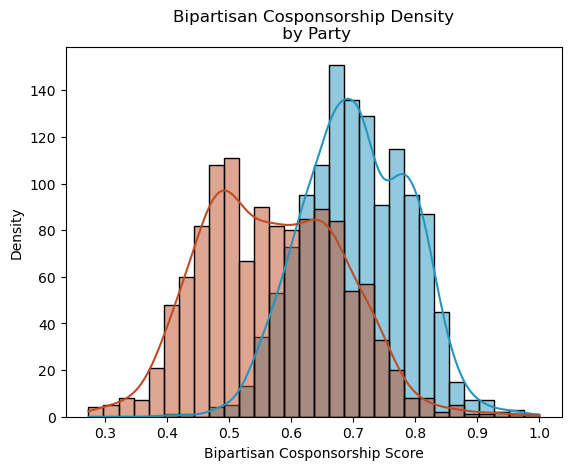

```python
# chart bipart score density by party
sns.histplot(df, x = 'bipartisan_cosponsorship_score', kde = True, hue = 'party',
           legend = False, palette = {'Republican': '#be4d25', 'Democrat': '#2596be'})
plt.xlabel("Bipartisan Cosponsorship Score")
plt.ylabel("Density")
plt.title("Bipartisan Cosponsorship Density\n by Party")
```

```python
# interactive plot
# bipart score by pagerank centrality

repubs = alt.Chart(df[df.party == 'Republican']).mark_point(color = 'red', opacity = 0.1).encode(
    x = alt.X('bipartisan_cosponsorship_score', title = 'Bipartisan Cosponsorship'),
    y = alt.Y('pagerank', title = 'Pagerank Centrality'),
    tooltip = ['first_name', 'last_name', 'state', 'district']
).properties(title = "Bipartisanship and Centrality by Party")

dems = alt.Chart(df[df.party == 'Democrat']).mark_circle(color = 'blue', opacity = 0.1).encode(
    x = alt.X('bipartisan_cosponsorship_score'),
    y = alt.Y('pagerank'),
    tooltip = ['first_name', 'last_name', 'state', 'district']
)

dem_line = dems.transform_regression('bipartisan_cosponsorship_score', 'pagerank').mark_line(color = 'blue')

repub_line = repubs.transform_regression('bipartisan_cosponsorship_score', 'pagerank').mark_line(color = 'red')

dems.interactive() + repubs.interactive() + dem_line + repub_line
```

[interactive chart not shown]

## Hypothesis Testing

### T-test

Is the difference between Republican and Democrat bipartisan cosponsorship scores statistically significant?

```python
ttest_ind(df[df.party == 'Democrat'].bipartisan_cosponsorship_score,
          df[df.party == 'Republican'].bipartisan_cosponsorship_score)
```

```
Ttest_indResult(statistic=34.12611404107078, pvalue=8.773133824228066e-210)
```

The p-value here is miniscule, as expected -- with this many observations, the visual difference was bound to be significant.

### ANOVA

Is the relationship between bipartisan cosponsorship and pagerank similarly significant? Is the difference by party between the 2 OLS regression lines significant?

```python
# log pagerank b/c 2-way ANOVA assumes normally distributed dependant variable
df['log_pagerank'] = np.log(df.pagerank)

# fit linear model
lm = smf.ols("log_pagerank ~ bipartisan_cosponsorship_score + bipartisan_cosponsorship_score:C(party)", data = df).fit()

# get ANOVA stats
table = sm.stats.anova_lm(lm, typ = 2)
table
```

|  | sum_sq | df | F | PR(>F) |
| --- | --- | --- | --- | --- |
| bipartisan_cosponsorship_score | 12.331208 | 1.0 | 23.909080 | 1.074201e-06 |
| bipartisan_cosponsorship_score:C(party) | 42.168937 | 1.0 | 81.761696 | 3.007388e-19 |
| Residual | 1285.259427 | 2492.0 | NaN | NaN |

Both p-values are very small, so we now know that not only is the relationship between bipartisan cosponsorship score and pagerank centrality significant (if quite weak), but the difference between parties is too.